# Lab 9 Submission

Yeonjoon Choi

2023-03-18

# Lip cancer

Here is the lip cancer data given to you in terribly unreproducible and error-prone format.

- `aff.i` is proportion of male population working outside in each region
- `observe.i` is observed deaths in each region
- `expect.i` is expected deaths, based on region-specific age distribution and national-level age-specific mortality rates.

```r
observe.i <- c(
  5,13,18,5,10,18,29,10,15,22,4,11,10,22,13,14,17,21,25,6,11,21,13,5,19,18,14,17,3,10,
  7,3,12,11,6,16,13,6,9,10,4,9,11,12,23,18,12,7,13,12,12,13,6,14,7,18,13,9,6,8,7,6,16,4,6,12,5,5,
  17,5,7,2,9,7,6,12,13,17,5,5,6,12,10,16,10,16,15,18,6,12,6,8,33,15,14,18,25,14,2,73,13,14,6,20,8,
  12,10,3,11,3,11,13,11,13,10,5,18,10,23,5,9,2,11,9,11,6,11,5,19,15,4,8,9,6,4,4,2,12,12,11,9,7,7,
  8,12,11,23,7,16,46,9,18,12,13,14,14,3,9,15,6,13,13,12,8,11,5,9,8,22,9,2,10,6,10,12,9,11,32,5,11,
  9,11,11,0,9,3,11,11,11,5,4,8,9,30,110)
expect.i <- c(
    6.17,8.44,7.23,5.62,4.18,29.35,11.79,12.35,7.28,9.40,3.77,3.41,8.70,9.57,8.18,4.35,
    4.91,10.66,16.99,2.94,3.07,5.50,6.47,4.85,9.85,6.95,5.74,5.70,2.22,3.46,4.40,4.05,5.74,6.36,5.13,
    16.99,6.19,5.56,11.69,4.69,6.25,10.84,8.40,13.19,9.25,16.98,8.39,2.86,9.70,12.12,12.94,9.77,
    10.34,5.09,3.29,17.19,5.42,11.39,8.33,4.97,7.14,6.74,17.01,5.80,4.84,12.00,4.50,4.39,16.35,6.02,
    6.42,5.26,4.59,11.86,4.05,5.48,13.13,8.72,2.87,2.13,4.48,5.85,6.67,6.11,5.78,12.31,10.56,10.23,
    2.52,6.22,14.29,5.71,37.93,7.81,9.86,11.61,18.52,12.28,5.41,61.96,8.55,12.07,4.29,19.42,8.25,
    12.90,4.76,5.56,11.11,4.76,10.48,13.13,12.94,14.61,9.26,6.94,16.82,33.49,20.91,5.32,6.77,8.70,
    12.94,16.07,8.87,7.79,14.60,5.10,24.42,17.78,4.04,7.84,9.89,8.45,5.06,4.49,6.25,9.16,12.37,8.40,
    9.57,5.83,9.21,9.64,9.09,12.94,17.42,10.29,7.14,92.50,14.29,15.61,6.00,8.55,15.22,18.42,5.77,
    18.37,13.16,7.69,14.61,15.85,12.77,7.41,14.86,6.94,5.66,9.88,102.16,7.63,5.13,7.58,8.00,12.82,
    18.75,12.33,5.88,64.64,8.62,12.09,11.11,14.10,10.48,7.00,10.23,6.82,15.71,9.65,8.59,8.33,6.06,
    12.31,8.91,50.10,288.00)
aff.i <- c(0.2415,0.2309,0.3999,0.2977,0.3264,0.3346,0.4150,0.4202,0.1023,0.1752,
        0.2548,0.3248,0.2287,0.2520,0.2058,0.2785,0.2528,0.1847,0.3736,0.2411,
        0.3700,0.2997,0.2883,0.2427,0.3782,0.1865,0.2633,0.2978,0.3541,0.4176,
        0.2910,0.3431,0.1168,0.2195,0.2911,0.4297,0.2119,0.2698,0.0874,0.3204,
        0.1839,0.1796,0.2471,0.2016,0.1560,0.3162,0.0732,0.1490,0.2283,0.1187,
        0.3500,0.2915,0.1339,0.0995,0.2355,0.2392,0.0877,0.3571,0.1014,0.0363,
        0.1665,0.1226,0.2186,0.1279,0.0842,0.0733,0.0377,0.2216,0.3062,0.0310,
        0.0755,0.0583,0.2546,0.2933,0.1682,0.2518,0.1971,0.1473,0.2311,0.2471,
        0.3063,0.1526,0.1487,0.3537,0.2753,0.0849,0.1013,0.1622,0.1267,0.2376,
        0.0737,0.2755,0.0152,0.1415,0.1344,0.1058,0.0545,0.1047,0.1335,0.3134,
        0.1326,0.1222,0.1992,0.0620,0.1313,0.0848,0.2687,0.1396,0.1234,0.0997,
        0.0694,0.1022,0.0779,0.0253,0.1012,0.0999,0.0828,0.2950,0.0778,0.1388,
        0.2449,0.0978,0.1144,0.1038,0.1613,0.1921,0.2714,0.1467,0.1783,0.1790,
        0.1482,0.1383,0.0805,0.0619,0.1934,0.1315,0.1050,0.0702,0.1002,0.1445,
        0.0353,0.0400,0.1385,0.0491,0.0520,0.0640,0.1017,0.0837,0.1462,0.0958,
        0.0745,0.2942,0.2278,0.1347,0.0907,0.1238,0.1773,0.0623,0.0742,0.1003,
        0.0590,0.0719,0.0652,0.1687,0.1199,0.1768,0.1638,0.1360,0.0832,0.2174,
        0.1662,0.2023,0.1319,0.0526,0.0287,0.0405,0.1616,0.0730,0.1005,0.0743,
        0.0577,0.0481,0.1002,0.0433,0.0838,0.1124,0.2265,0.0436,0.1402,0.0313,
        0.0359,0.0696,0.0618,0.0932,0.0097)
```

## Question 1

Explain a bit more what the `expect.i` variable is. For example, if a particular area has an expected deaths of 6, what does this mean?

## Answer:

Expected deaths is the implied number of lip cancer deaths for a particular region given that region’s age structure and the national level age-specific mortality rates for lip cancer. For example, an expected number of deaths of 6 would mean that for particular region, we would expect 6 lip cancer deaths if this region were to experience the same age speficit mortality rates as at the national level.

## Question 2

Run three different models in Stan with three different set-up’s for estimating $\theta_i$, that is the relative risk of lip cancer in each region:

1. Intercept $\alpha_i$ is same in each region $= \alpha$ (with covariate)
2. $\alpha_i$ is different in each region and modeled separately (with covariate)
3. $\alpha_i$ is different in each region and the intercept is modeled hierarchically (with covariate)

## Answer

$$y_i | \theta_i \sim \text{Poisson}(\theta_i \cdot e_i)$$

Look at three models for $\log \theta_i$

Model 1:

$$\log \theta_i = \alpha + \beta x_i$$
Model 2:

$$\log \theta_i = \alpha_i + \beta x_i$$
Model 3:

$$\log \theta_i = \alpha_i + \beta x_i$$

with
$$\alpha_i \sim N(\mu, \sigma^2)$$
## Model 1:

```r
require(tidyverse)
require(rstan)
require(tidybayes)

stan_data = list(y = observe.i,
                  log_e = log(expect.i),
                  N = length(observe.i),
                  x = aff.i - mean(aff.i))

mod1 = stan(data = stan_data, file = 'model1.stan', refresh = 0)
```

## Model 2:

```r
stan_data = list(y = observe.i,
                  log_e = log(expect.i),
                  N = length(observe.i),
                  x = aff.i - mean(aff.i))

mod2 = stan(data = stan_data, file = 'model2.stan', refresh = 0)
```

## Model 3:

```r
stan_data <- list(y = observe.i,
                  log_e = log(expect.i),
                  N = length(observe.i),
                  x = aff.i - mean(aff.i))

mod3 = stan(data = stan_data, file = 'model3.stan', refresh = 0)
```

## Question 3

Make two plots (appropriately labeled and described) that illustrate the differences in estimated $\theta_i$’s across regions and the differences in $\theta$s across models.

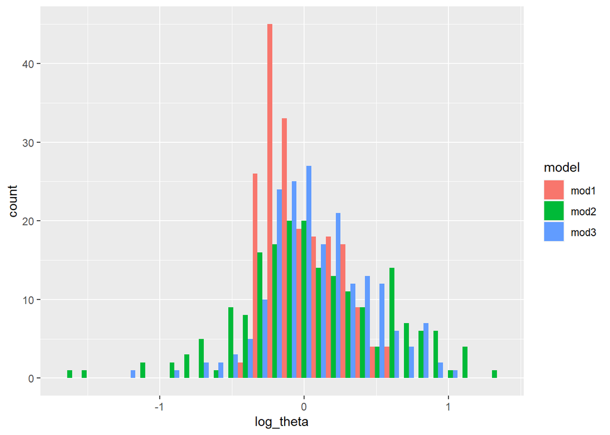

```r
res_mod1 = mod1 |>
  gather_draws(log_theta[i]) |>
  median_qi() |>
  rename(median_mod1 = .value,
         lower_mod1 = .lower,
         upper_mod1 = .upper) |>
  dplyr::select(i, median_mod1:upper_mod1)

res_mod2 = mod2 |>
  gather_draws(log_theta[i]) |>
  median_qi() |>
  rename(median_mod2 = .value,
         lower_mod2 = .lower,
         upper_mod2 = .upper) |>
  dplyr::select(i, median_mod2:upper_mod2)

res_mod3 = mod3 |>
  gather_draws(log_theta[i]) |>
  median_qi() |>
  rename(median_mod3 = .value,
         lower_mod3 = .lower,
         upper_mod3 = .upper) |>
  dplyr::select(i, median_mod3:upper_mod3)

res = res_mod1 |>
  left_join(res_mod2) |>
  left_join(res_mod3)
res |>
  select(median_mod1,
        median_mod2,
        median_mod3) |>
  pivot_longer(median_mod1:median_mod3, names_to = "model", values_to = "log_theta") |>
  mutate(model = str_remove(model, "median_")) |>
  ggplot(aes(log_theta, fill = model)) +
  geom_histogram(position = 'dodge')
```

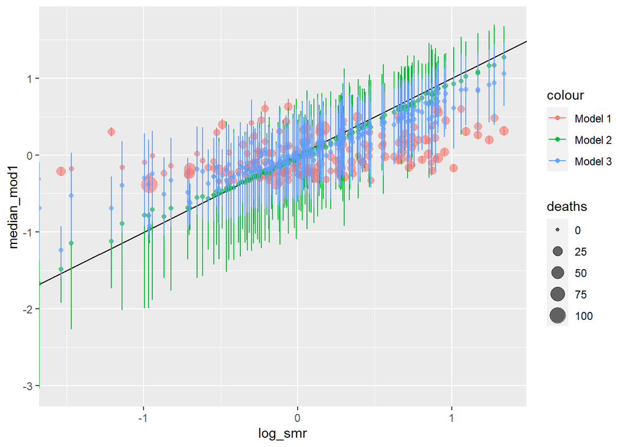

```r
res |>
  mutate(deaths = observe.i) |>
  mutate(log_smr = log(observe.i/expect.i)) |>
  ggplot(aes(log_smr, median_mod1, color = 'Model 1')) +
  geom_point(aes(size = deaths), alpha = 0.6) +
  geom_errorbar(aes(ymin = lower_mod1, ymax = upper_mod1, color = 'Model 1'))+
  geom_abline(slope = 1, intercept = 0)+
  geom_point(aes(log_smr, median_mod2, color = 'Model 2'), alpha = 0.6)+
  geom_errorbar(aes(ymin = lower_mod2, ymax = upper_mod2, color = 'Model 2'))+
  geom_point(aes(log_smr, median_mod3, color = 'Model 3'), alpha = 0.6)+
  geom_errorbar(aes(ymin = lower_mod3, ymax = upper_mod3, color = 'Model 3'))
```

the uncertainty level fro model 1 is less but it is more truncated towards points.